# Number of membership associations per 10,000 people — City

Author

Manuel Alcalá Kovalski

Published

October 28, 2025

```r
library(tidyverse)
library(here)
library(sf)
library(censusapi)
library(tigris)
library(janitor)
library(tidylog)
library(naniar)
options(tigris_use_cache = TRUE)
```

## Process:

This notebook creates city-level `Number of membership associations per 10,000 people` (one of two Social Capital Gates Mobility Metrics)

Data downloaded from: Census ZCTA Business Patterns (CBP)

1. download social organization data from the Census API
2. import and clean the data file (collapse to unique ZCTAs)
3. merge with the 2010 ZCTA -> 2010 Census Place and 2020 ZCTA -> 2021 Census Place crosswalk
4. collapse estimates to unique Places
5. check against Census Place file & limit to population cutoff Places
6. use crosswalk population data to construct the ratio (Numerator/Denominator)
7. add data quality tag, final file cleaning, visualize metric and export to .csv file

## Download social organization data

We pull our data from `library(censusapi)`.

**Note:** This will require a [Census API key](https://api.census.gov/data/key_signup.html). Add the key to `census_api_key-template.R` and then delete the word “template” from the filename.

It is sourced below

```r
source(here::here("06_neighborhoods", "R", "census_api_key.R"))
```

## Import and clean the CBP data file

This means:

- fill in fips missing zeroes,
- isolate to only the following NAICS,
- collapse & keep only relevant variables, and
- add the year of these data.

Below are the codes/associations included in the County Health Rankings metric. See [here](https://www.countyhealthrankings.org/health-data/community-conditions/social-and-economic-factors/safety-and-social-support/social-associations?year=2025) for more

Codes: 813410, 713950, 713910, 713940, 711211, 813110, 813940, 813930, 813910, and 813920.

These codes consistently denote the same categories across NAICS2012 and NAICS2017. You can check this by visitng the [NAICS page](https://www.census.gov/naics/)

**Note:** Running the chunk below can take some time, avoid re-running it to prevent hitting API rate limits. The file is exported and read in once again to avoid re-running API requests.

```r
fetch_cbp_data <- function(year, naics_codes_to_keep) {
  tryCatch({
    Sys.sleep(2) # avoid rate limiting
    naics_var <- if_else(year >= 2014 & year <= 2016, "NAICS2012", "NAICS2017")
    dataset_name <- if_else(year >= 2019, "cbp", "zbp")

    getCensus(
      name = dataset_name,
      vintage = year,
      vars = c("EMP", "ESTAB", naics_var),
      region = "zipcode:*"
    ) %>%
      as_tibble() %>%
      mutate(year = year,
             naics = as.numeric(!!sym(naics_var))) %>%
      filter(naics %in% naics_codes_to_keep) %>%
      select(zcta_code = zip_code, year, orgs = ESTAB) %>%
      drop_na(orgs) %>%
      summarize(count_orgs = sum(orgs), .by = c("year", "zcta_code"))

  }, error = function(e) {
    stop("Error fetching data for year ", year, ": ", e$message)
    NULL
  })
}

# Fetch and combine data
years <- 2014:2023
naics_codes_to_keep <- c(813410, 713950, 713910, 713940, 711211,
                           813110, 813940, 813930, 813910, 813920)

data_dir <- here("06_neighborhoods", "social-capital", "data")
if (!dir.exists(data_dir)) dir.create(data_dir, recursive = TRUE)

cbp_zcta <- map(years, function(yr) {
  file_path <- file.path(data_dir, paste0("cbp_zcta_", yr, ".csv"))
  if (file.exists(file_path)) {
    message("Loading local data for year ", yr)
    read_csv(file_path, show_col_types = FALSE)
  } else {
    message("Fetching data for year ", yr)
    data_year <- fetch_cbp_data(yr, naics_codes_to_keep)
    if (!is.null(data_year)) write_csv(data_year, file_path)
    data_year
  }
}) %>%
  compact() %>%
  bind_rows()

head(cbp_zcta)
```

```
# A tibble: 6 × 3
   year zcta_code count_orgs
  <dbl> <chr>          <dbl>
1  2014 00501              2
2  2014 01001             11
3  2014 01002             32
4  2014 01003              6
5  2014 01004              1
6  2014 01005              6
```

```r
if(!file.exists(here::here("06_neighborhoods/social-capital/data/cbp_zcta.csv"))){
  write_csv(cbp_zcta, "06_neighborhoods/social-capital/data/cbp_zcta.csv")
}
```

```r
cbp_zcta <- read_csv(here("06_neighborhoods/social-capital/data/cbp_zcta.csv"))
```

**Check:** Are all ZCTA codes 5 digits?

```r
stopifnot(
  all(str_length(cbp_zcta$zcta_code) == 5)
)
```

**Check:** Are all years present?

```r
# Test if all expected years are present in the resulting data
test_years <- cbp_zcta %>%
  pull(year) %>% # Extract the years column
  unique() %>% # Get unique years
  sort() # Sort the years

# Check if the expected years match the test years
if (all(years %in% test_years)) {
  message("Test passed: All expected years are present in the data.")
} else {
  missing_years <- setdiff(years, test_years)
  stop("Test failed: Missing years - ", paste(missing_years, collapse = ", "))
}
```

## Merge with the 2020 ZCTA -> 2021 Census Place crosswalk

Since Census data are only available at the ZCTA level and not at the place level, we need to crosswalk from ZCTA’s to Places.

Download the 2010/2020 ZCTA -> 2010/2021 Census Place crosswalk file from [Geocorr 2022](https://mcdc.missouri.edu/applications/geocorr2022.html) as follows:

- Ctrl-click select every state to get the whole country (where is says Select the state(s) (including DC and/or PR) to process:)
- Then, choose ZIP/ZCTA from the 2010/2020 Geographies in the left rectangle, and Place (city. town, etc) from the 2010/2020 Geographies in the right one
- Choose population as the weighting variable you’re using to do interpolation
- In Output Options, pick CSV
- Check select for Generate second allocation factor AFACT2 showing portion of target geocodes in source geocodes
- Hit Run Request, and it will generate the crosswalk for you!

Now, import and clean the 2010/2020 ZCTA -> 2010/2021 Census Place crosswalk file to prepare for merging

```r
zcta_20_place_21_xwalk <-
  read_csv(here("06_neighborhoods/social-capital/data/2020_ZCTA_2021_Census_Places_Crosswalk.csv"), skip = 1) %>%
  as_tibble() %>%
  clean_names() |>
  rename(
    zcta_code = zip_census_tabulation_area,
    state_fips = state_code,
    place = place_code
  )

zcta_10_place_10_xwalk <-
  read_csv(here("06_neighborhoods/social-capital/data/2010_ZCTA_2010_Census_Places_Crosswalk.csv"), skip = 1) %>%
  as_tibble() %>%
  clean_names() |>
  rename(
    zcta_code = zip_census_tabulation_area,
    state_fips = state_code,
    place = place_code,
    zcta_to_place_allocation_factor = zcta5_to_placefp_allocation_factor,
    place_to_zcta_allocation_factor = placefp_to_zcta5_allocation_factor
  )
```

Make an indicator for ZCTAs that fall wholly into a Place vs. partially (`zcta_to_place_allocation_factor < 1`)

```r
zcta_20_place_21_xwalk <-
  zcta_20_place_21_xwalk %>%
  mutate(zcta_fully_within_place_binary = case_when(
    zcta_to_place_allocation_factor == 1 ~ 1,
    zcta_to_place_allocation_factor < 1 ~ 0
  ))

zcta_10_place_10_xwalk <-
  zcta_10_place_10_xwalk %>%
  mutate(zcta_fully_within_place_binary = case_when(
    zcta_to_place_allocation_factor == 1 ~ 1,
    zcta_to_place_allocation_factor < 1 ~ 0
  ))
```

Now, select the relevant crosswalk variables and combine the 2010 ZCTA’s to 2010 places crosswalk with the 2020 ZCTA’s to 2021 Places crosswalk.

```r
zcta_20_place_21_xwalk <-
  zcta_20_place_21_xwalk %>%
  select(
    zcta_code, state_fips, place, place_name, zcta_to_place_allocation_factor,
    place_to_zcta_allocation_factor, zcta_fully_within_place_binary
  )


zcta_10_place_10_xwalk <-
  zcta_10_place_10_xwalk %>%
  select(
    zcta_code, state_fips, place, place_name, zcta_to_place_allocation_factor,
    place_to_zcta_allocation_factor, zcta_fully_within_place_binary
  )

zcta_place_xwalk <- bind_rows(zcta_20_place_21_xwalk, zcta_10_place_10_xwalk)
```

Merge the ZIP/Places crosswalk into the CBP ZIP-level data file

```r
merged_associations_zcta_city <-
  cbp_zcta %>%
  left_join(zcta_place_xwalk, by = c("zcta_code"))
```

**Check:** Are there any missing values in the merged data for `count_orgs`?

```r
stopifnot(
  sum(is.na(merged_associations_zcta_city$count_orgs)) == 0
)
```

## Collapse estimates to unique Places

First, as a data quality marker we create a new variable that tracks the number of ZCTAs falling in each place

```r
merged_associations_zcta_city <-
  merged_associations_zcta_city %>%
  mutate(
    count_zctas_in_place = n(),
    .by = c(year, place, place_name)
  )
```

Create the merged file where the SA numerator (`count_orgs`) is aggregated to the place level (multiply `count_orgs` by zcta to place allocation factor and then summarize to place) and also include total ZCTAs in Place (`zcta_total`) & how many of those fully fall within the Place (`zctas_in`)

```r
merged_associations_zcta_city <-
  merged_associations_zcta_city %>%
  # multiply `count_orgs` by the allocation factor (a measure of how much of the zcta falls within the place)
  mutate(count_orgs_afact = count_orgs * zcta_to_place_allocation_factor) %>%
  summarize(
    zcta_total = mean(count_zctas_in_place),
    zctas_in = sum(zcta_fully_within_place_binary),
    total_org = sum(count_orgs_afact),
    .by = c(year, state_fips, place)
  )
```

**Check:** Is there exactly 1 missing row per year in the `total_org` variable?

```r
stopifnot(
  merged_associations_zcta_city %>%
    filter(is.na(total_org)) %>%
    nrow() == length(years)
)
```

Looking at we can see that this observation per year corresponds to a row with missing `state_fips`, `place`, and `zctas_in`

```r
  merged_associations_zcta_city %>%
    filter(is.na(total_org))
```

```
# A tibble: 10 × 6
    year state_fips place zcta_total zctas_in total_org
   <dbl> <chr>      <chr>      <dbl>    <dbl>     <dbl>
 1  2014 <NA>       <NA>        2930       NA        NA
 2  2015 <NA>       <NA>        2894       NA        NA
 3  2016 <NA>       <NA>        2875       NA        NA
 4  2017 <NA>       <NA>         631       NA        NA
 5  2018 <NA>       <NA>         625       NA        NA
 6  2019 <NA>       <NA>         600       NA        NA
 7  2020 <NA>       <NA>         591       NA        NA
 8  2021 <NA>       <NA>         581       NA        NA
 9  2022 <NA>       <NA>         584       NA        NA
10  2023 <NA>       <NA>         553       NA        NA
```

We drop these missing values

```r
merged_associations_zcta_city <-
  merged_associations_zcta_city %>%
  drop_na(total_org)
```

## Check against Census Place file & limit to population cutoff Places

Import the updated population-cutoff Places file for the relevant years

```r
places_pop <-
  read_csv(here("geographic-crosswalks/data/place-populations.csv")) %>%
  rename(state_fips = state) %>%
  filter(year %in% years)
```

**Check:** Are there 485 places in 2015-2017 and 486 places in 2018-2022 in the population-cutoff file?

```r
stopifnot(
  count(places_pop, year) %>%
    filter(year <= 2017) |>
    pull(n) %>%
    unique() == 485
)

stopifnot(
  count(places_pop, year) %>%
    filter(year > 2017) |>
    pull(n) %>%
    unique() == 486
)
```

Join `places_pop` with `merged_associations_zcta_city` in order to get the final associations (numerator) city data.

```r
associations_city_data <-
  places_pop %>%
  left_join(merged_associations_zcta_city,
    by = c("year", "place", "state_fips")
  )
```

We can see that there are 485 observations pre-2018 and 486 after 2018

```r
associations_city_data |>
  count(year)
```

```
# A tibble: 10 × 2
    year     n
   <dbl> <int>
 1  2014   485
 2  2015   485
 3  2016   485
 4  2017   485
 5  2018   486
 6  2019   486
 7  2020   486
 8  2021   486
 9  2022   486
10  2023   486
```

## Use crosswalk population data to construct the ratio (Numerator/Denominator)

## Create the social associations per 10,000 people metric

Now, we create the social associations metric by dividing the population by 10,000 and then dividing the numerator by that value.

We also round the ratio metric to one decimal point as they do in County Health Rankings.

```r
associations_city_data <-
  associations_city_data %>%
  mutate(
    pop_ratio = population / 1e4,
    count_membership_associations_per_10k = round(total_org / pop_ratio, digits = 1)
  )
```

## Add data quality tag, final file cleaning and export to .csv file

## Create quality variable

Add the necessary components to the crosswalk for producing a data quality flag. The methodology is borrowed from the Puma to County Crosswalk notebook

Create flags in the ZCTA-place crosswalk for places where a high percentage of the data comes from outside of the places Per agreed upon guidance, 75% or more from the place is good, below 35% is bad, in between is marginal. This is calculated by taking the product of percentage of ZCTA in the place and percentage of place in the ZCTA for each ZCTA-place pairing, and summing across the place

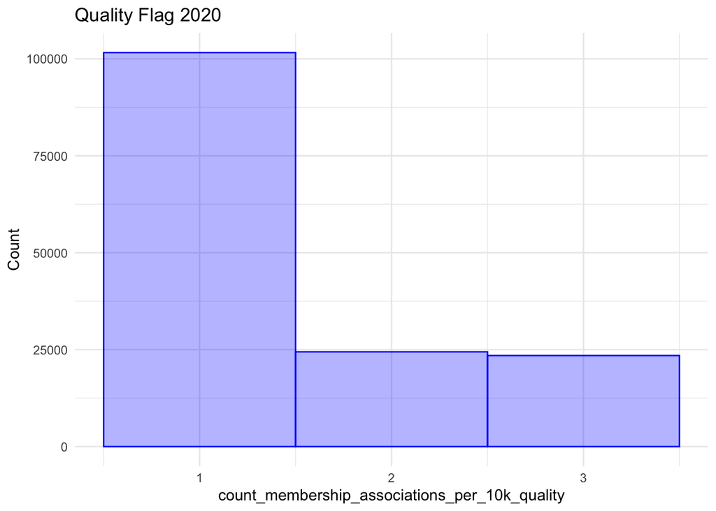

```r
crosswalk_data_quality <-
  zcta_place_xwalk |>
  mutate(products = place_to_zcta_allocation_factor * zcta_to_place_allocation_factor) |>
  mutate(
    sum_products = sum(products),
    .by = c("state_fips", "place")
  ) |>
  mutate(
    count_membership_associations_per_10k_quality =
      case_when(
        sum_products >= 0.75 ~ 1,
        sum_products >= 0.35 ~ 2,
        sum_products < 0.35 ~ 3
      )
  ) |>
  select(state_fips, place, count_membership_associations_per_10k_quality)

crosswalk_data_quality |>
  ggplot(aes(x = count_membership_associations_per_10k_quality)) +
  geom_histogram(color = "blue", fill = alpha("blue", 0.3), binwidth = 1.0) +
  theme_minimal() +
  ggtitle("Quality Flag 2020") +
  ylab("Count")
```

```r
associations_city_data <-
  associations_city_data %>%
  left_join(crosswalk_data_quality, by = c("state_fips", "place")) |>
  select(year, state = state_fips, place, count_membership_associations_per_10k, count_membership_associations_per_10k_quality) %>%
  arrange(
    year, state, place,
    count_membership_associations_per_10k,
    count_membership_associations_per_10k_quality
  ) %>%
  distinct()
```

**Check:** Are there any missing values in the metric?

```r
stopifnot(
  sum(is.na(associations_city_data %>%
    .[["count_membership_associations_per_10k"]])) == 0
)
```

## Visualize Metric

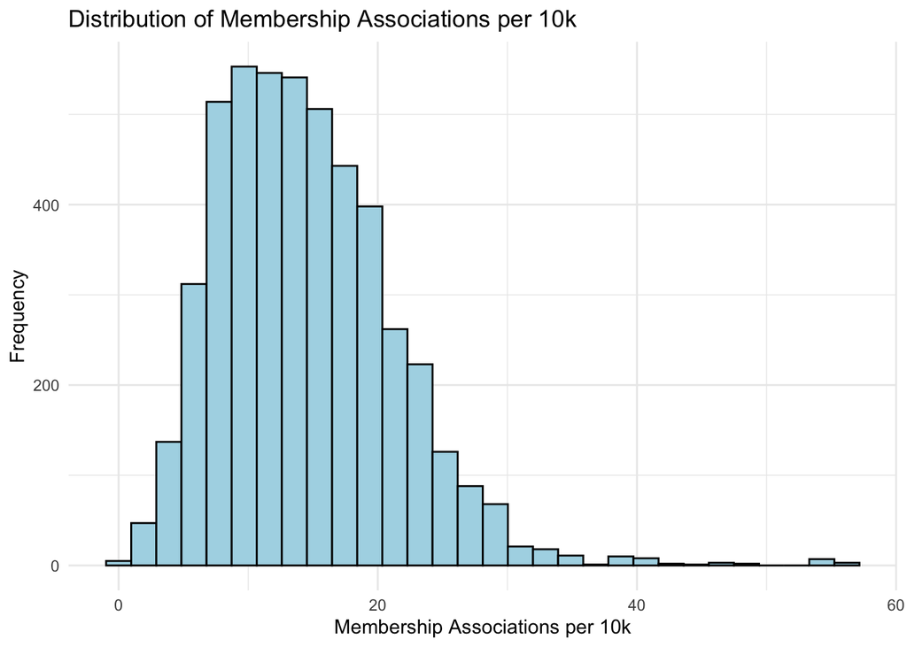

```r
ggplot(associations_city_data, aes(x = count_membership_associations_per_10k)) +
  geom_histogram(bins = 30, color = "black", fill = "lightblue") +
  labs(
    title = "Distribution of Membership Associations per 10k",
    x = "Membership Associations per 10k", y = "Frequency"
  ) +
  theme_minimal()
```

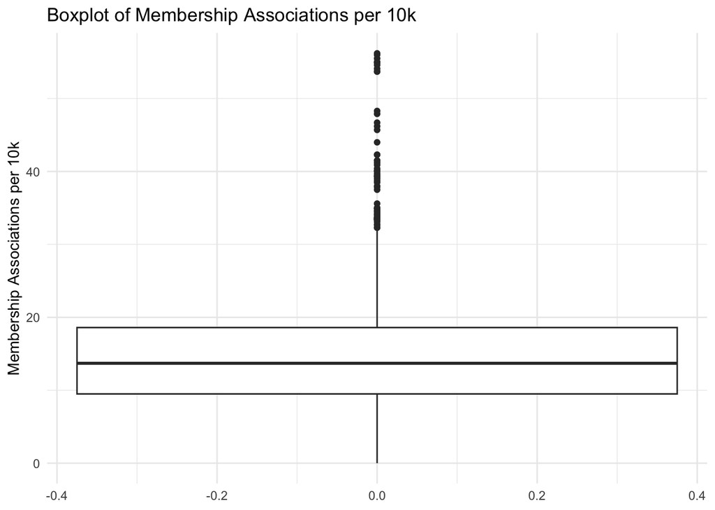

```r
ggplot(associations_city_data, aes(y = count_membership_associations_per_10k)) +
  geom_boxplot() +
  labs(
    title = "Boxplot of Membership Associations per 10k",
    y = "Membership Associations per 10k"
  ) +
  theme_minimal()
```

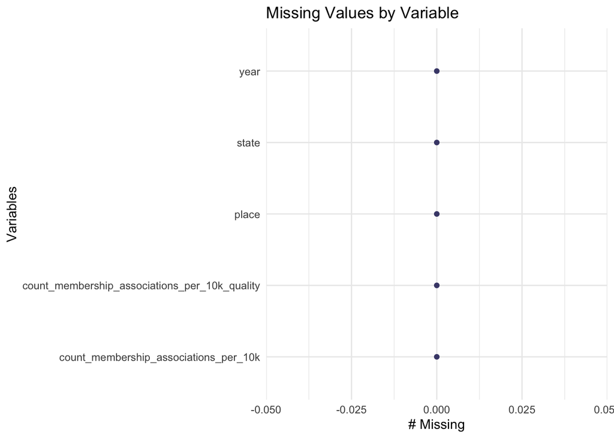

```r
# Visualize missing data
gg_miss_var(associations_city_data) +
  labs(title = "Missing Values by Variable")
```

There is a precipitous decline in population-standarized association counts from 2016 to 2017

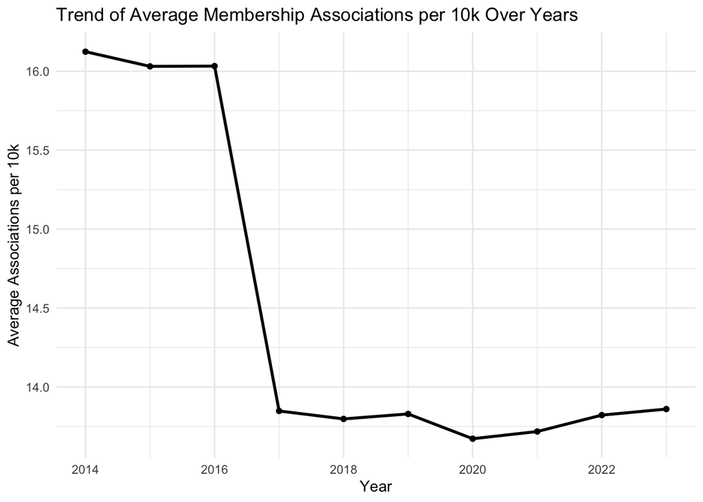

```r
yearly_avg <- associations_city_data %>%
  group_by(year) %>%
  summarise(avg_associations = mean(count_membership_associations_per_10k, na.rm = TRUE))

ggplot(yearly_avg, aes(x = year, y = avg_associations)) +
  geom_line(linewidth = 1) +
  geom_point() +
  labs(
    title = "Trend of Average Membership Associations per 10k Over Years",
    x = "Year", y = "Average Associations per 10k"
  ) +
  theme_minimal()
```

## Run Final Tests

```r
source(here("functions/testing/evaluate_final_data.R"))

evaluate_final_data(here("10a_final-evaluation", "evaluation_form_social_cap1_overall_place.csv"), associations_city_data, "place", subgroups = FALSE, confidence_intervals = FALSE)
```

```
[1] "This data passes all tests!"
```

## Save the final file

```r
associations_city_data %>%
  arrange(year, state, place) %>%
  write_csv(here("06_neighborhoods/social-capital/final/social_associations_all_city.csv"))
```